# Template for lab 7 report for BIOS 20152

Sarah Greta

## Programming exercises (self-check, not graded)

1. Write a function that takes the input variable and multiplies it by 1.03 $f(x) = 1.03x$.

```r
mul.fun <- function(x,y) {
  ans <- y*x
  return(ans)
}
y <- 1.03
```

2. Use the function to take a variable and multiply it by 1.03, replacing the old value of the variable. If the initial value is 5, the new value should be 5.15.

```r
x <- 5
x <- mul.fun(x,y)
print(x)
```

```
## [1] 5.15
```

3. Write a script to take a number and multiply it by 1.03 one hundred times **using a for loop and the function you created**. Starting with the initial value is 5, the script should return the value 96.093.

```r
nsteps <- 100
x <- 5
for (i in 1:nsteps) {
  x <- mul.fun(x,y)
}
print(x)
```

```
## [1] 96.09316
```

4. Modify the script above to save all the intermediate values of the number into a vector, and plot a graph of this vector vs. theiteration step (from 1 to 101).

```r
x <- rep(0, nsteps+1)
x[1] <- 5
for (i in 1:nsteps){
  x[i+1] <- mul.fun(x[i],y)
}
print(x)
```

```
##   [1]  5.000000  5.150000  5.304500  5.463635  5.627544  5.796370  5.970261
##   [8]  6.149369  6.333850  6.523866  6.719582  6.921169  7.128804  7.342669
##  [15]  7.562949  7.789837  8.023532  8.264238  8.512165  8.767530  9.030556
##  [22]  9.301473  9.580517  9.867933 10.163971 10.468890 10.782956 11.106445
##  [29] 11.439638 11.782828 12.136312 12.500402 12.875414 13.261676 13.659526
##  [36] 14.069312 14.491392 14.926133 15.373917 15.835135 16.310189 16.799495
##  [43] 17.303479 17.822584 18.357261 18.907979 19.475219 20.059475 20.661259
##  [50] 21.281097 21.919530 22.577116 23.254429 23.952062 24.670624 25.410743
##  [57] 26.173065 26.958257 27.767005 28.600015 29.458016 30.341756 31.252009
##  [64] 32.189569 33.155256 34.149914 35.174411 36.229643 37.316533 38.436029
##  [71] 39.589110 40.776783 42.000086 43.260089 44.557892 45.894628 47.271467
##  [78] 48.689611 50.150300 51.654809 53.204453 54.800586 56.444604 58.137942
##  [85] 59.882080 61.678543 63.528899 65.434766 67.397809 69.419743 71.502336
##  [92] 73.647406 75.856828 78.132533 80.476509 82.890804 85.377528 87.938854
##  [99] 90.577019 93.294330 96.093160
```

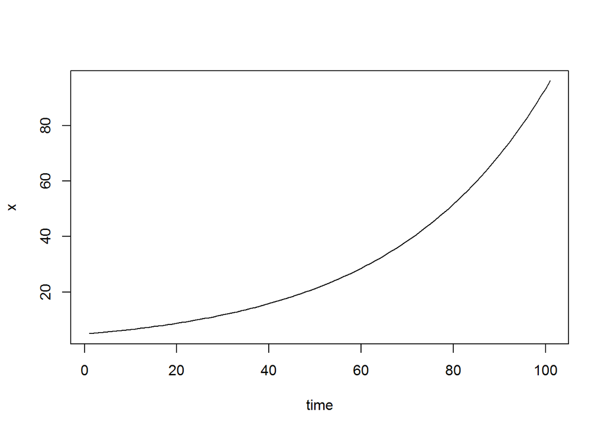

```r
time <- 0:nsteps+1
plot(time,x, t="l")
```

## Part 1: Numeric solutions of difference equations

In this part you will calculate numeric solutions of difference equations. Use the code from the last of the exercises above to write a script to iteratively update the variable for a specified number of steps and store it as a vector, and plot it as function of time. Hint: your code will be nearly identical for all the tasks, so once you get the first script to work properly, copy and paste it and modify the updating function.

For the following difference equations: 1) calculate the numerical solution for 100 steps staring with the given initial values; 2) plot the solution over time; 3) describe how the solution behaves in the long term and whether it depends on the initial value.

1. $$X(t + 1) = 0.9X(t)$$
   Initial values: $X(0) = 100; X(0) = 5$.

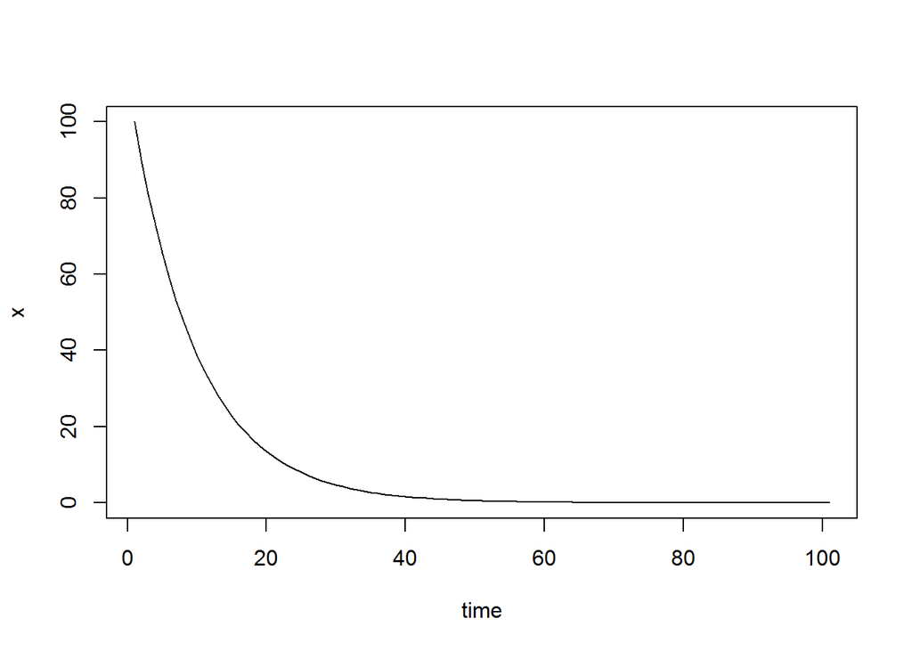

```r
fun1 <- function(x,y) {
  ans <- y*x
  return(ans)
}
nsteps <- 100
y <- 0.9
x <- rep(0, nsteps+1)
x[1] <- 100
for (i in 1:nsteps){
  x[i+1] <- fun1(x[i],y)
}
time <- 0:nsteps+1
plot(time, x, t="l")
```

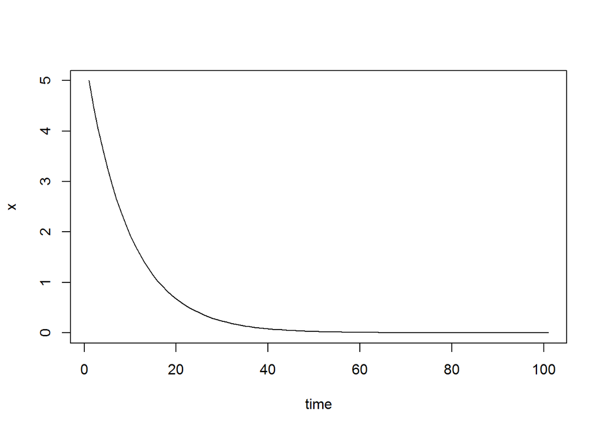

```r
x[1] <- 5
for (i in 1:nsteps){
  x[i+1] <- fun1(x[i],y)
}
plot(time, x, t="l")
```

2. $$X(t + 1) = 45 - 0.8X(t)$$
   Initial values: $X(0) = 20; X(0) = 0$.

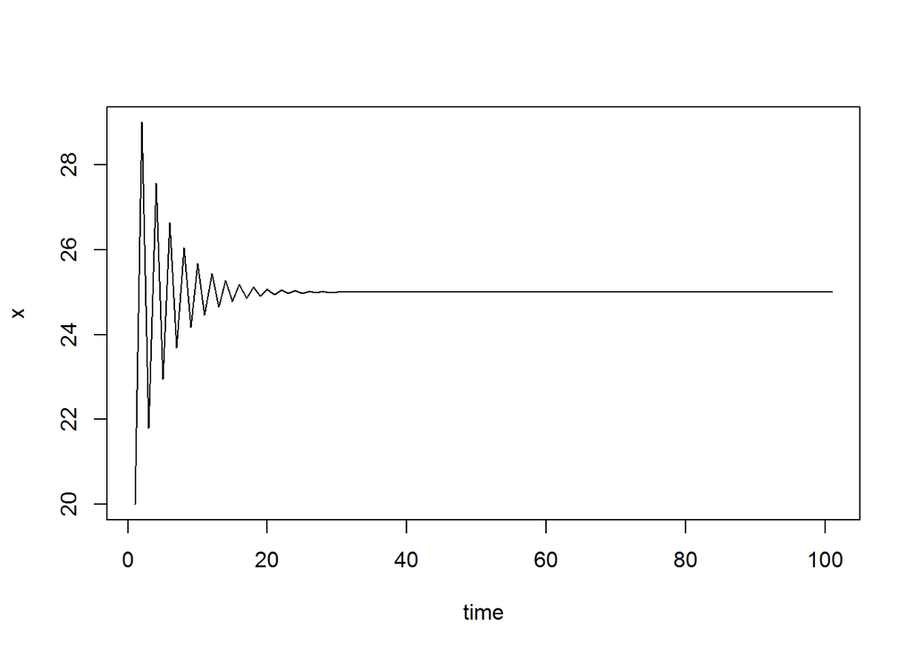

```r
fun1 <- function(x,m,b) {
  ans <- m-b*x
  return(ans)
}
m <- 45
b <- 0.8
nsteps <- 100
x <- rep(0, nsteps+1)
x[1] <- 20
for (i in 1:nsteps){
  x[i+1] <- fun1(x[i],m,b)
}
time <- 0:nsteps+1
plot(time, x, t="l")
```

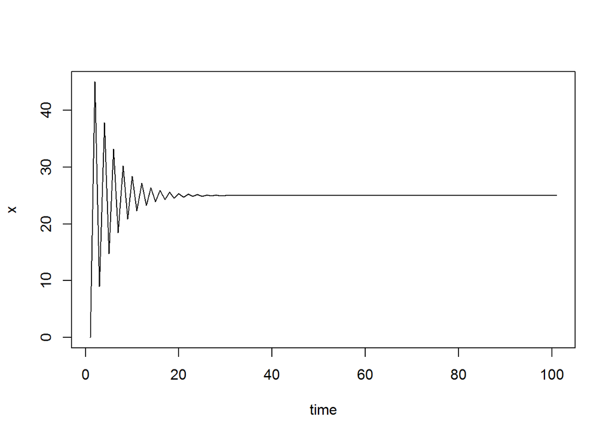

```r
x[1] <- 0
for (i in 1:nsteps){
  x[i+1] <- fun1(x[i],m,b)
}
plot(time, x, t="l")
```

The function oscillates around 25, but eventually converges in both cases. When the initial value is 20, the function only oscillates between 20 and 28, but when the initial value is 0, the function oscillates between 0 and 45.

3. $$X(t + 1) = 0.2X(t)(10 - X(t))$$
   Initial values: $X(0) = 2; X(0) = 9$.

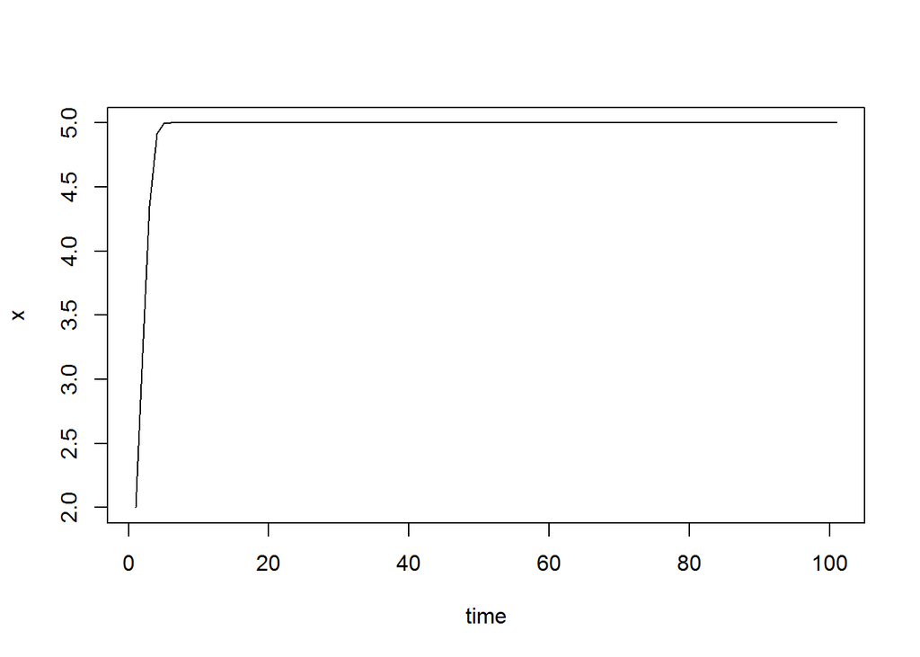

```r
fun1 <- function(x,m,b) {
  ans <- m*x*(b-x)
  return(ans)
}
nsteps <- 100
m <- 0.2
b <- 10
x <- rep(0, nsteps+1)
x[1] <- 2
for (i in 1:nsteps){
  x[i+1] <- fun1(x[i],m,b)
}
time <- 0:nsteps+1
plot(time, x, t="l")
```

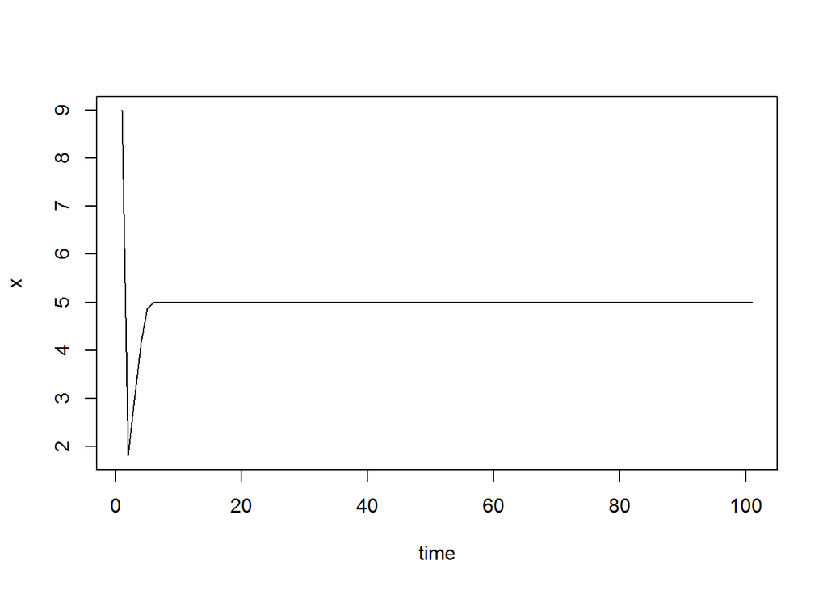

```r
x[1] <- 9
for (i in 1:nsteps){
  x[i+1] <- fun1(x[i],m,b)
}
plot(time, x, t="l")
```

## Forward Euler exercises (self-check, not graded)

In this section you will use the Forward Euler method to solve the ODE
$$\frac{dx}{dt} = 0.2 x$$
Here is an outline of the steps of Euler’s method:

- set time step dt, length of time Tmax, number of time steps Nstep
- write a function Upfunk(x,t) that defines the ODE which you want to solve (the function Upfunk(x,t) in dx/dt = Upfunk(x,t))
- initialize the vector of solution values y of length Nstep+1
- set the vector of time values t from 0 to Tmax of length Nstep+1
- set y[1] to the initial value for the ODE
- for loop with i starting at 1 to Nstep
  - assign y[i+1] to be y[i]+dt*Upfunk(y[i],t[i])
- plot numeric solution y as a function of time t
1. Calculate the numeric solution of the ODE for **one time step** using Forward Euler, for time step dt=0.1, starting with initial value x(0) = 5. Answer: 5.1

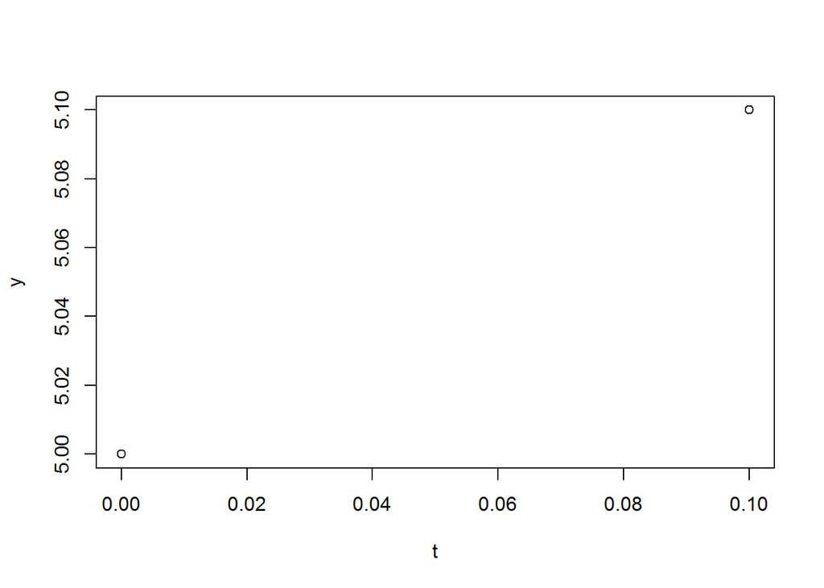

```r
dt <- 0.1
Tmax <- 1
Nstep <- 1
up.fun <- function(y,t){
  ans <- m*y
  return(ans)
}
m <- 0.2
y <- rep(0, Nstep+1)
t <- dt*(0:Nstep)
y[1] <- 5
for (i in 1:Nstep){
  y[i+1] <- y[i] + dt*up.fun(y[i],t[i])
}
plot(t,y)
```

2. Calculate the error of the numeric solution above by subtracting it from the exact (analytic) solution $x(t) = e^{0.2t}x(0)$, with the same initial value. Answer: about 0.001.

```r
exact.fun <- function(m,t,b){
  ans <- exp(m*t)*b
  return(ans)
}
m <- 0.2
b <- 5
t <- dt*(0:Nstep)
s <- exact.fun(m,t,b)
error <- s[2] - y[2]
print(error)
```

```
## [1] 0.0010067
```

3. Write a script to solve the ODE using the Forward Euler method based on the outline above. Set the time step dt=0.1 and report the solution **after 100 time steps**. Answer: 36.22323

```r
dt <- 0.1
Tmax <- 100
Nstep <- 100
up.fun <- function(y,t){
  ans <- m*y
  return(ans)
}
m <- 0.2
y <- rep(0, Nstep+1)
t <- dt*(0:Nstep)
y[1] <- 5
for (i in 1:Nstep){
  y[i+1] <- y[i] + dt*up.fun(y[i],t[i])
}
print(y)
```

```
##   [1]  5.000000  5.100000  5.202000  5.306040  5.412161  5.520404  5.630812
##   [8]  5.743428  5.858297  5.975463  6.094972  6.216872  6.341209  6.468033
##  [15]  6.597394  6.729342  6.863929  7.001207  7.141231  7.284056  7.429737
##  [22]  7.578332  7.729898  7.884496  8.042186  8.203030  8.367091  8.534432
##  [29]  8.705121  8.879223  9.056808  9.237944  9.422703  9.611157  9.803380
##  [36]  9.999448 10.199437 10.403425 10.611494 10.823724 11.040198 11.261002
##  [43] 11.486222 11.715947 11.950266 12.189271 12.433056 12.681718 12.935352
##  [50] 13.194059 13.457940 13.727099 14.001641 14.281674 14.567307 14.858653
##  [57] 15.155826 15.458943 15.768122 16.083484 16.405154 16.733257 17.067922
##  [64] 17.409281 17.757466 18.112616 18.474868 18.844365 19.221253 19.605678
##  [71] 19.997791 20.397747 20.805702 21.221816 21.646252 22.079177 22.520761
##  [78] 22.971176 23.430600 23.899212 24.377196 24.864740 25.362034 25.869275
##  [85] 26.386661 26.914394 27.452682 28.001735 28.561770 29.133006 29.715666
##  [92] 30.309979 30.916179 31.534502 32.165192 32.808496 33.464666 34.133959
##  [99] 34.816638 35.512971 36.223231
```

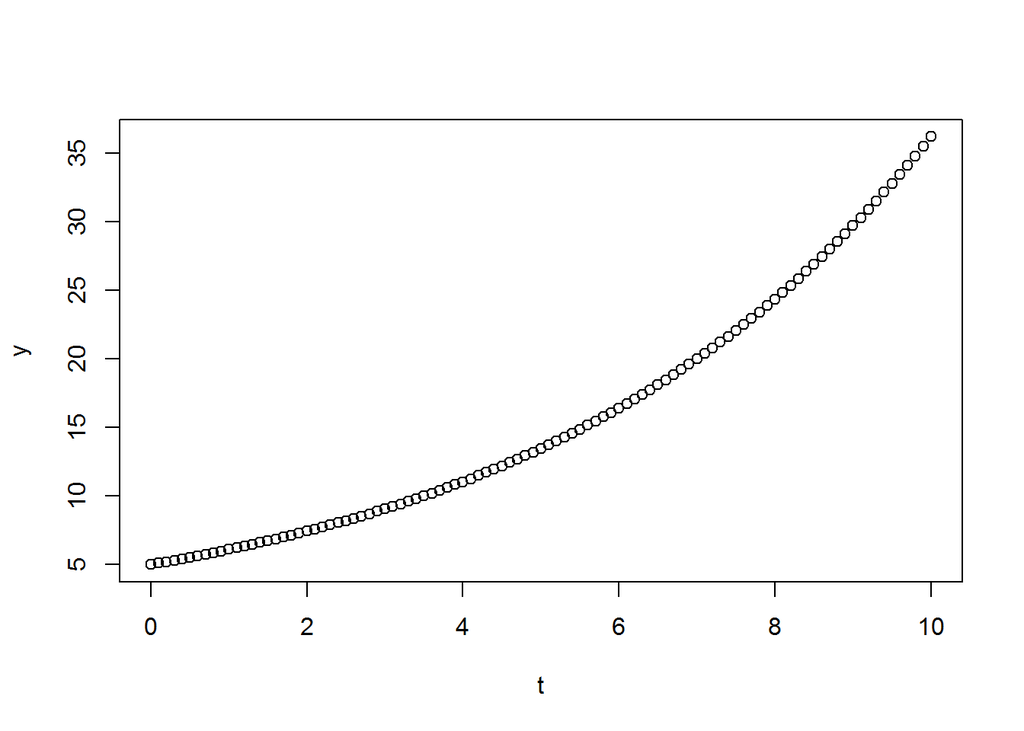

```r
solution3 <- y[101]
plot(t,y)
```

4. Change the time step to be dt=0.01 and report the solution **after 1000 time steps**. Answer: 36.87156.

```r
dt <- 0.01
Tmax <- 1000
Nstep <- 1000
up.fun <- function(y,t){
  ans <- m*y
  return(ans)
}
m <- 0.2
y <- rep(0, Nstep+1)
t <- dt*(0:Nstep)
y[1] <- 5
for (i in 1:Nstep){
  y[i+1] <- y[i] + dt*up.fun(y[i],t[i])
}
print(y)
```

```
##    [1]  5.000000  5.010000  5.020020  5.030060  5.040120  5.050200
##    [7]  5.060301  5.070421  5.080562  5.090723  5.100905  5.111107
##   [13]  5.121329  5.131571  5.141835  5.152118  5.162423  5.172747
##   [19]  5.183093  5.193459  5.203846  5.214254  5.224682  5.235132
##   [25]  5.245602  5.256093  5.266605  5.277138  5.287693  5.298268
##   [31]  5.308865  5.319482  5.330121  5.340782  5.351463  5.362166
##   [37]  5.372890  5.383636  5.394403  5.405192  5.416003  5.426835
##   [43]  5.437688  5.448564  5.459461  5.470380  5.481320  5.492283
##   [49]  5.503268  5.514274  5.525303  5.536353  5.547426  5.558521
##   [55]  5.569638  5.580777  5.591939  5.603123  5.614329  5.625558
##   [61]  5.636809  5.648082  5.659378  5.670697  5.682039  5.693403
##   [67]  5.704790  5.716199  5.727631  5.739087  5.750565  5.762066
##   [73]  5.773590  5.785137  5.796708  5.808301  5.819918  5.831558
##   [79]  5.843221  5.854907  5.866617  5.878350  5.890107  5.901887
##   [85]  5.913691  5.925518  5.937369  5.949244  5.961142  5.973065
```

[output cut: 152 more lines]

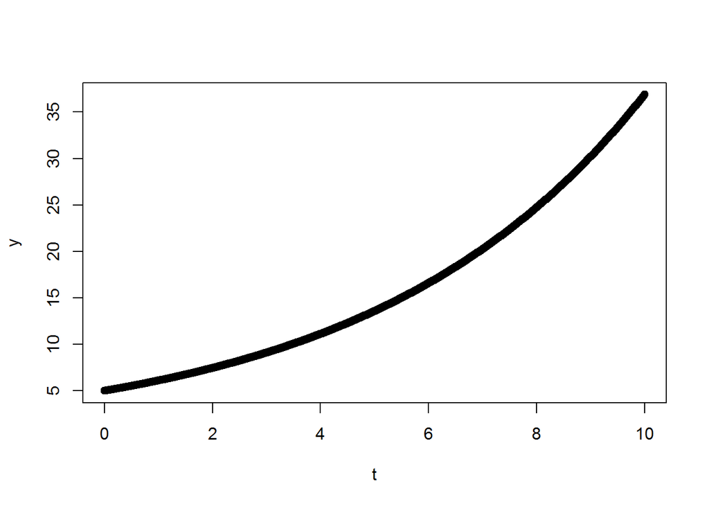

```r
solution4 <- y[1001]
plot(t,y)
```

5. Compute the errors of the two numeric solutions by subtracting them from the values obtained from the analytic solution at the same time. Answers: for dt=0.1 the error is 0.722, for dt=0.01 the error is 0.0737.

```r
m <- 0.2
b <- 5
dt <- 0.1
Nstep <- 100
t <- dt*(0:Nstep)
s <- exact.fun(m,t,b)
error <- s[101] - solution3
print(error)
```

```
## [1] 0.7220499
```

```r
dt <- 0.01
Nstep <- 1000
t <- dt*(0:Nstep)
s <- exact.fun(m,t,b)
error <- s[1001] - solution4
print(error)
```

```
## [1] 0.07371854
```

## Error and the time step in Forward Euler solutions

In this part you will solve the linear population model ODE:
$${dN}{dt} = (b- d) N$$
The model parameters are capita birth and death rates ($b$ and $d$, respectively), which may be expressed in percent population change per year (e.g. $d= 0.12$ is a death rate of 12% per year). Assume that the initial population is 100,000 individuals, and perform the following tasks:

1. Write a Forward Euler script to solve this ODE for any given values of $b$ and $d$ (they should be inputs into your defining function). Set $b=0.5$ and $d=0.12$, plot the numeric solution, and report whether the solution behaves as you would expect it to, for $Tmax=50$ and $dt=0.1$. Describe the behavior of the solution of the ODE over time.

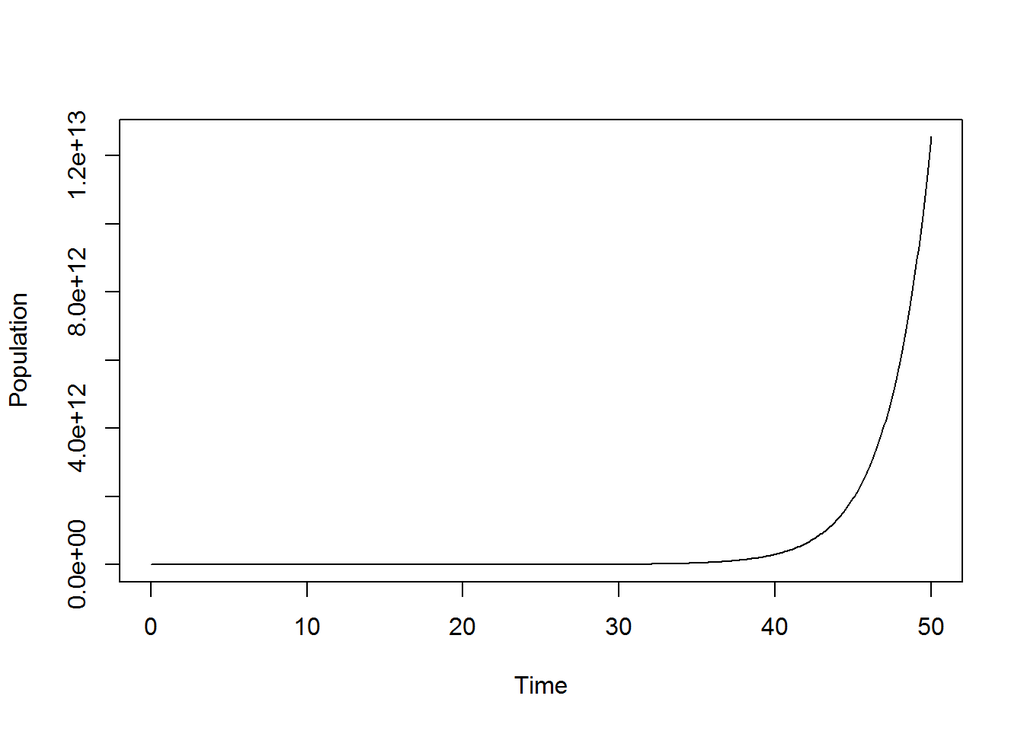

```r
pop.model <- function(b,d,N) {
  ans <- (b-d)*N
  return(ans)
}
dt <- 0.1
Tmax <- 50
Nstep <- Tmax/dt
b <- 0.5
d <- 0.12
N <- rep(0, Nstep+1)
N[1] <- 100000
t <- dt*(0:Nstep)
for (i in 1:Nstep){
  N[i+1] <- N[i] + dt*pop.model(b,d,N[i])
}
plot(t,N, type="l", xlab="Time", ylab="Population")
```

The solution to the ODE shows that the population increases very slowly and then around the 40th year, the plot increases extremely quickly. It increases minimally at first and then starts to increase much more quickly. After 50 years, the population is close to 1.25e13 people and the solution to the ODE will continue to increase.

2. Change the birth rate to $b=0.01$ and run the calculation again for the same values of $Tmax$ and $dt$. Plot the solution and compare its behavior to the one in the previous task.

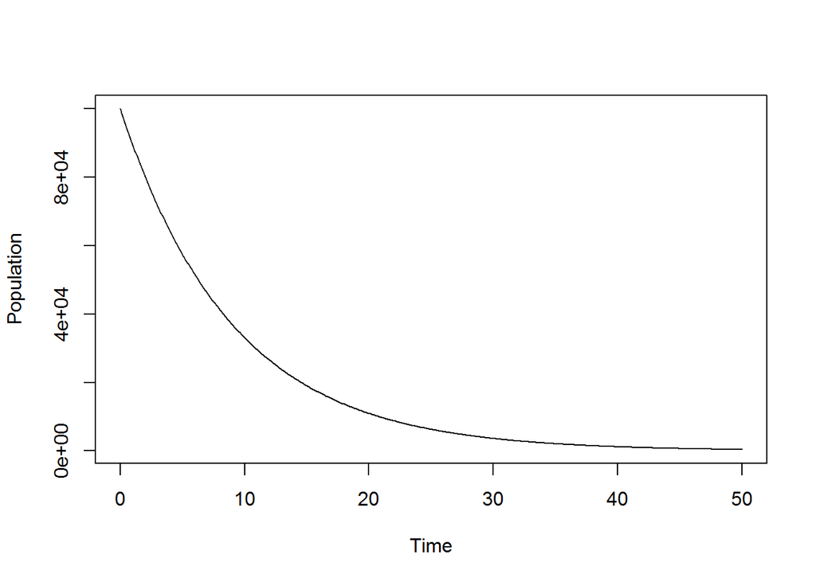

```r
b <- 0.01
d <- 0.12
Nstep <- Tmax/dt
N <- rep(0, Nstep+1)
N[1] <- 100000
t <- dt*(0:Nstep)
for (i in 1:Nstep){
  N[i+1] <- N[i] + dt*pop.model(b,d,N[i])
}
plot(t,N, type="l", xlab="Time", ylab="Population")
```

The solution in this task is very different than the solution in the first task. In this task, the solution decays almost exponentially to 0 after 50 years. In the other graph, the population started increasing extremely quickly around the 40th year whereas in this graph the population decreases.

3. Calculate the numeric solution of the ODE with different time steps: $dt = 1, 5, 10$. Plot the solutions and repot how they behave for larger values of the time step. What time step would you consider optimal for this problem?

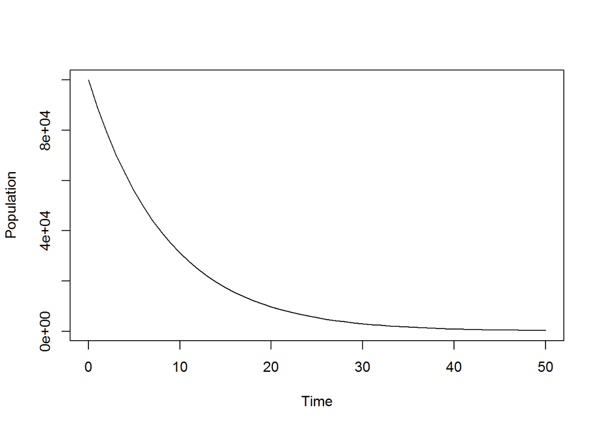

```r
b <- 0.01
d <- 0.12
dt <- 1
Nstep <- Tmax/dt
N <- rep(0, Nstep+1)
N[1] <- 100000
t <- dt*(0:Nstep)
for (i in 1:Nstep){
  N[i+1] <- N[i] + dt*pop.model(b,d,N[i])
}
plot(t,N, type="l", xlab="Time", ylab="Population")
```

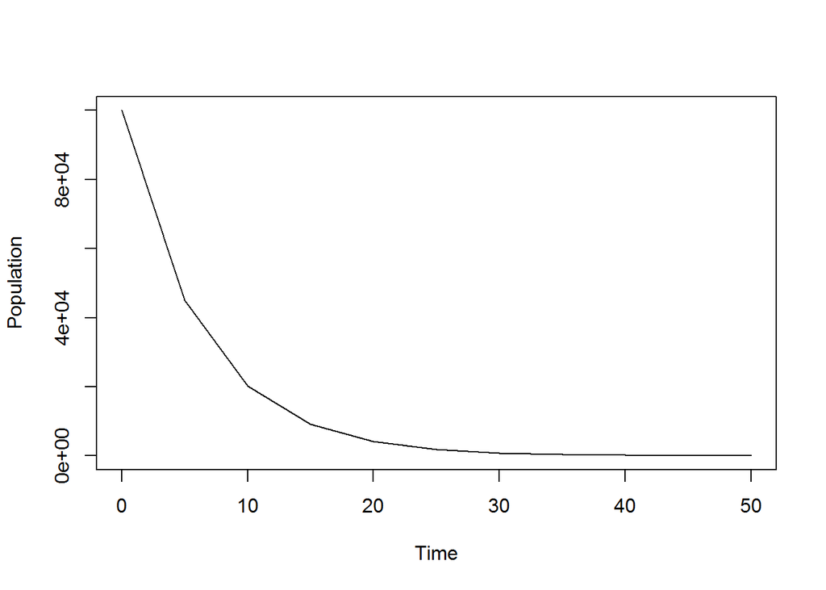

```r
dt <- 5
Nstep <- Tmax/dt
N <- rep(0, Nstep+1)
N[1] <- 100000
t <- dt*(0:Nstep)
for (i in 1:Nstep){
  N[i+1] <- N[i] + dt*pop.model(b,d,N[i])
}
plot(t,N, type="l", xlab="Time", ylab="Population")
```

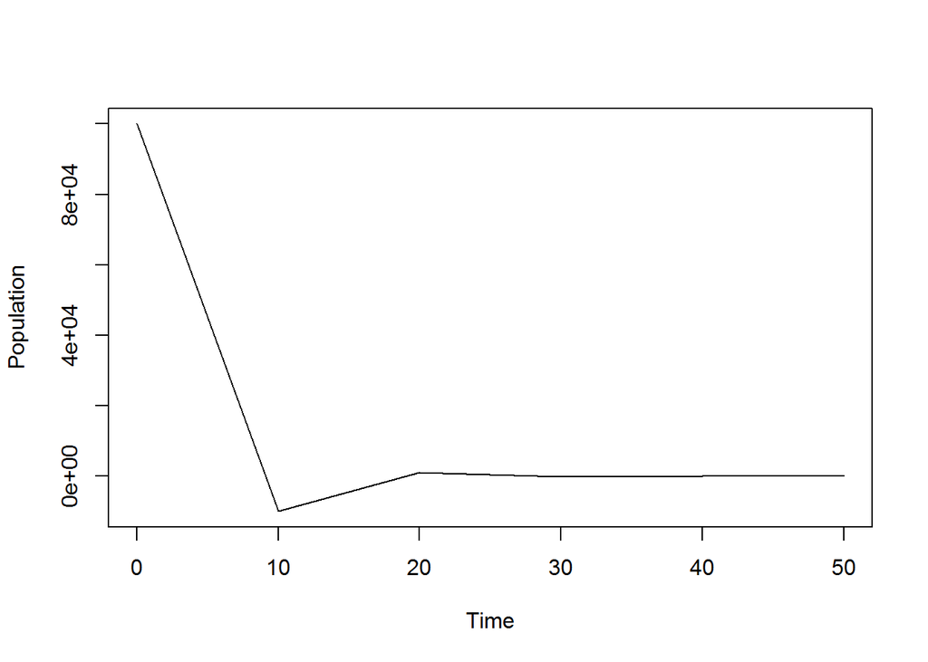

```r
dt <- 10
Nstep <- Tmax/dt
N <- rep(0, Nstep+1)
N[1] <- 100000
t <- dt*(0:Nstep)
for (i in 1:Nstep){
  N[i+1] <- N[i] + dt*pop.model(b,d,N[i])
}
plot(t,N, type="l", xlab="Time", ylab="Population")
```

When dt=1, the graph decays very similarly to the graph in the previous task, approaching 0 around the 40th year. When dt=5, the graph decays to 0 by around the 30th year, but it does not do so smoothly. The graph decreases at the same slope until the 5th year and then the graph starts decreasing more slowly until it reaches the 10th year, where is starts to decrease more slowly and so on. When dt=10, the graph decays very quickly to 0. The plot decreases linearly until the 10th year, where it reaches a point below 0. Then the plot increaes slowly until the 20th year, where it reaches a point above 0. Then the plot decreases to 0 and plateaus there. Out of these three options for dt, the optimal time step would be 1.

4. Find the analytic solution of the ODE for $b=0.5$ and $d=0.12$. Use your FE code to compute and plot the numerical solution with $dt=0.1$ and the analytic solution on the time interval from 0 to 50 years. Calculate and plot the vector of errors (difference between the analytic and numerical solution) and plot it over time. Describe how the error behaves in this plot.

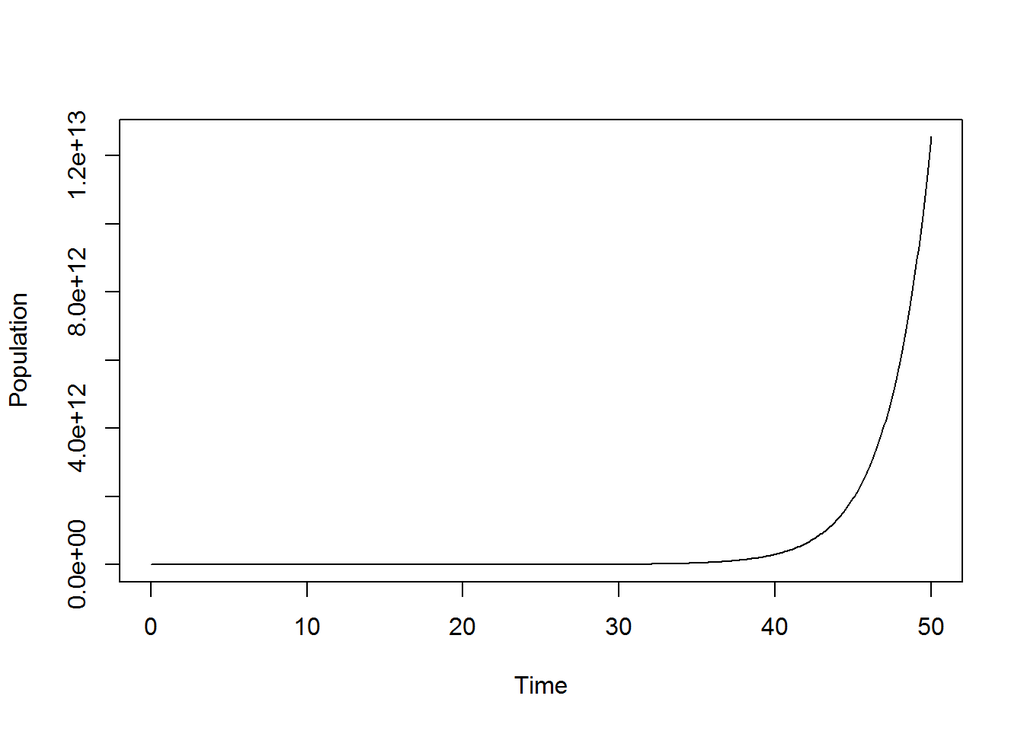

```r
dt <- 0.1
b <- 0.5
d <- 0.12
Nstep <- Tmax/dt
N <- rep(0, Nstep+1)
N[1] <- 100000
t <- dt*(0:Nstep)
for (i in 1:Nstep){
  N[i+1] <- N[i] + dt*pop.model(b,d,N[i])
}
plot(t,N, type="l", xlab="Time", ylab="Population")
```

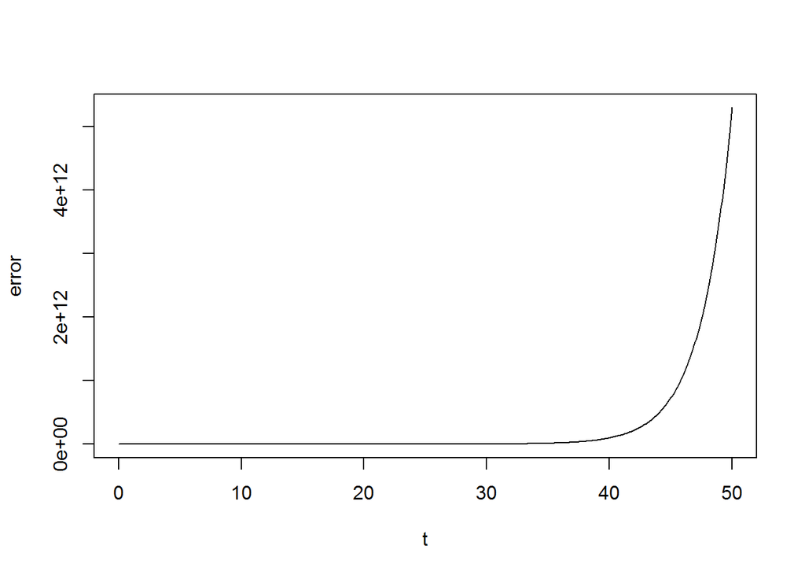

```r
analytic.pop.model <- function(b,d,N0,t){
  ans <- N0*exp((b-d)*t)
  return(ans)
}
analyticN <- analytic.pop.model(b,d,N[1],t)
error <- analyticN - N
plot(t, error, type ="l")
```

The error stays close to 0 until the 43rd year, where it starts to increase very quickly.

5. Compute the average error of the numerical solution as the sum of absolute values of the differences between the analytic solution vector $x$ and the numerical solution vector $y$, divided by the total number of time steps. Keeping the same parameters $b=0.5$, and $d=0.12$, calculate the average error of the numerical solution for five values of the time step: $dt=0.1, 0.05, 0.01, 0.005, 0.001$ and $Tmax=50$. Report by what factor the error changes for each decrease in the time step.

```r
average.error <- function(e,s){
  ans <- sum(abs(e))/s
  return(ans)
}
b <- 0.5
d <- 0.12
average.error(error,Nstep)
```

```
## [1] 271663334355
```

```r
dt <- 0.05
Nstep <- Tmax/dt
N <- rep(0, Nstep+1)
N[1] <- 100000
t <- dt*(0:Nstep)
for (i in 1:Nstep){
  N[i+1] <- N[i] + dt*pop.model(b,d,N[i])
}
analyticN <- analytic.pop.model(b,d,N[1],t)
error <- analyticN - N
average.error(error,Nstep)
```

```
## [1] 147384411364
```

```r
dt <- 0.01
Nstep <- Tmax/dt
N <- rep(0, Nstep+1)
N[1] <- 100000
t <- dt*(0:Nstep)
for (i in 1:Nstep){
  N[i+1] <- N[i] + dt*pop.model(b,d,N[i])
}
analyticN <- analytic.pop.model(b,d,N[1],t)
error <- analyticN - N
average.error(error,Nstep)
```

```
## [1] 31566759363
```

```r
dt <- 0.005
Nstep <- Tmax/dt
N <- rep(0, Nstep+1)
N[1] <- 100000
t <- dt*(0:Nstep)
for (i in 1:Nstep){
  N[i+1] <- N[i] + dt*pop.model(b,d,N[i])
}
analyticN <- analytic.pop.model(b,d,N[1],t)
error <- analyticN - N
average.error(error,Nstep)
```

```
## [1] 15922403611
```

```r
dt <- 0.001
Nstep <- Tmax/dt
N <- rep(0, Nstep+1)
N[1] <- 100000
t <- dt*(0:Nstep)
for (i in 1:Nstep){
  N[i+1] <- N[i] + dt*pop.model(b,d,N[i])
}
analyticN <- analytic.pop.model(b,d,N[1],t)
error <- analyticN - N
average.error(error,Nstep)
```

```
## [1] 3207009269
```

When the time step changes from 0.1 to 0.05, the average error decreases by a factor of 1.84323. When the time step changes from 0.05 to 0.01, the average error decreases by a factor of 4.668975. When the time step changes from 0.01 to 0.005, the average error decreases by a factor of 1.982537. When the time step changes from 0.005 to 0.001, the average error decreases by a factor of 4.964876.

6. Change the birth rate to $b=0.01$ and again calculate and plot the numerical solution along with the analytic solution for the same values of $Tmax$ and $dt$. Calculate and plot the vector of errors (difference between the analytic and numerical solution) and plot it over time. Describe how the error behaves in this plot.

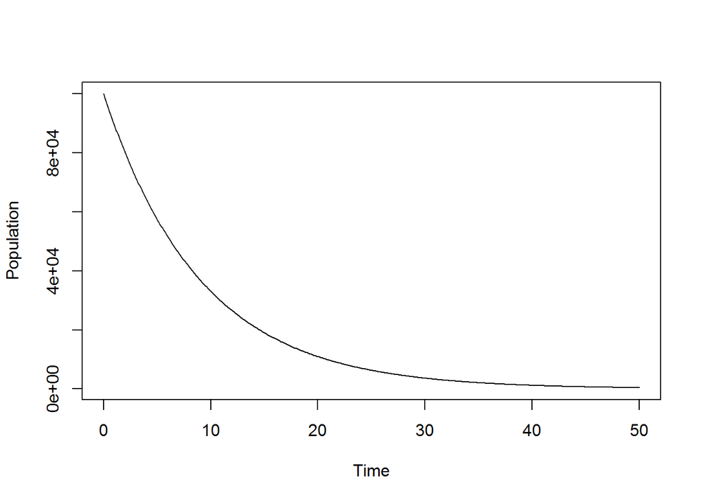

```r
b <- 0.01
d <- 0.12
dt <- 0.1
Nstep <- Tmax/dt
N <- rep(0, Nstep+1)
N[1] <- 100000
t <- dt*(0:Nstep)
for (i in 1:Nstep){
  N[i+1] <- N[i] + dt*pop.model(b,d,N[i])
}
plot(t,N, type="l", xlab="Time", ylab="Population")
```

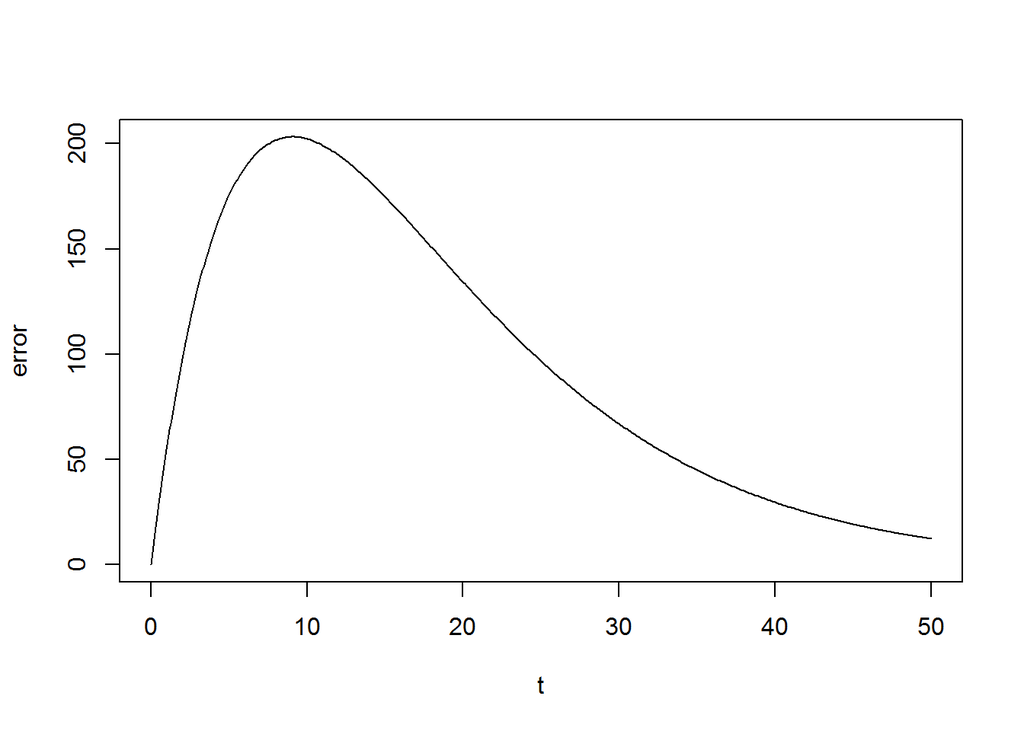

```r
analyticN <- analytic.pop.model(b,d,N[1],t)
error <- analyticN - N
plot(t,error,type="l")
```

In this plot the error increases quickly until it peaks at the 10th year and then starts to slowly decrease.

7. Keeping parameters $b=0.01$ and $d=0.12$, repeat task 5: calculate the average error of the numerical solution for five values of the time step: $dt=0.1, 0.05, 0.01, 0.005, 0.001$ and $Tmax=50$. Report by what factor the error changes for each decrease in the time step.

```r
average.error(error,Nstep)
```

```
## [1] 97.56825
```

```r
dt <- 0.05
Nstep <- Tmax/dt
N <- rep(0, Nstep+1)
N[1] <- 100000
t <- dt*(0:Nstep)
for (i in 1:Nstep){
  N[i+1] <- N[i] + dt*pop.model(b,d,N[i])
}
analyticN <- analytic.pop.model(b,d,N[1],t)
error <- analyticN - N
average.error(error,Nstep)
```

```
## [1] 48.72798
```

```r
dt <- 0.01
Nstep <- Tmax/dt
N <- rep(0, Nstep+1)
N[1] <- 100000
t <- dt*(0:Nstep)
for (i in 1:Nstep){
  N[i+1] <- N[i] + dt*pop.model(b,d,N[i])
}
analyticN <- analytic.pop.model(b,d,N[1],t)
error <- analyticN - N
average.error(error,Nstep)
```

```
## [1] 9.736608
```

```r
dt <- 0.005
Nstep <- Tmax/dt
N <- rep(0, Nstep+1)
N[1] <- 100000
t <- dt*(0:Nstep)
for (i in 1:Nstep){
  N[i+1] <- N[i] + dt*pop.model(b,d,N[i])
}
analyticN <- analytic.pop.model(b,d,N[1],t)
error <- analyticN - N
average.error(error,Nstep)
```

```
## [1] 4.867742
```

```r
dt <- 0.001
Nstep <- Tmax/dt
N <- rep(0, Nstep+1)
N[1] <- 100000
t <- dt*(0:Nstep)
for (i in 1:Nstep){
  N[i+1] <- N[i] + dt*pop.model(b,d,N[i])
}
analyticN <- analytic.pop.model(b,d,N[1],t)
error <- analyticN - N
average.error(error,Nstep)
```

```
## [1] 0.9734585
```

When the time step changes from 0.1 to 0.05, the average error decreases by a factor of 2.002394. When the time step changes from 0.05 to 0.01, the average error decreases by a factor of 5.004616. When the time step changes from 0.01 to 0.005, the average error decreases by a factor of 2.000231. When the time step changes from 0.005 to 0.001, the average error decreases by a factor of 5.000462.

## Part 3: ODE model of drug concentration

The following ODE is a model for the rate of change of concentration of acetaminophen (in $\mu$ g/mL), with A representing the acetaminophen concentration, $k$ is the first-order rate constant of elimination, and S(t) is the (possibly time-dependent) rate of administration of the drug.
$$\frac{dA}{dt} = -kA + S(t)$$
The elimination half-life of acetaminophen is about 3 hours, which corresponds to a first-order rate constant of k=-0.23.

1. Use your Forward Euler script from above with the defining function modified to match the equation above with *S(t)=0*. Calculate the numerical solution for 24 hours, with initial concentration *A(0) = 15* for 24 hours with timestep *dt=0.1*. Describe how the solution behaves in the long term, try a couple of different initial values and comment on whether it depends on the initial value. Then gradually increase the time step dt and report at what value the numeric solution substantially changes.

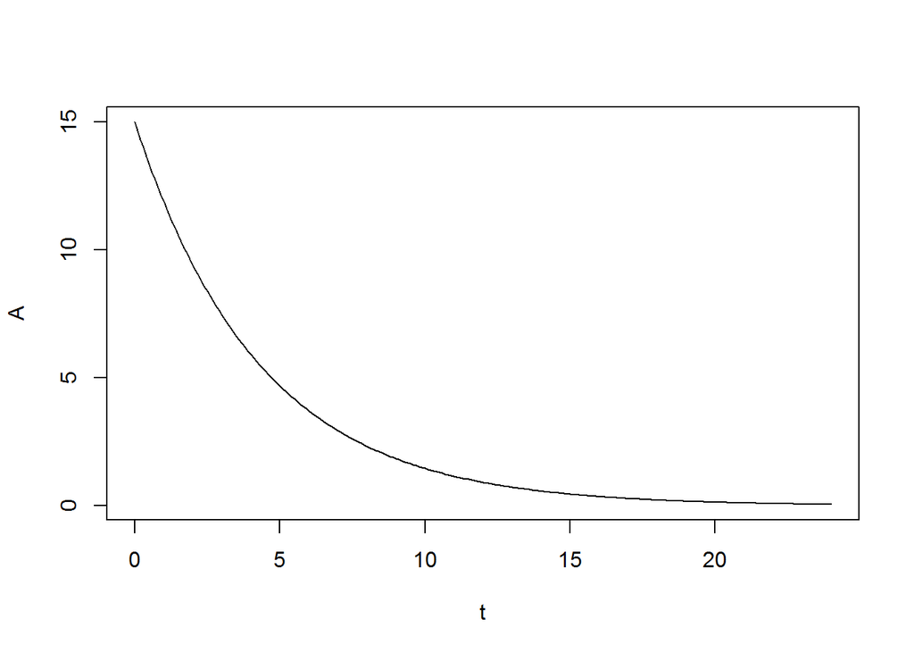

```r
acetamin.model <- function(k,a,s) {
  ans <- -k*a + s
  return(ans)
}
s <- 0
k <- 0.23
dt <- 0.1
Tmax <- 24
Nstep <- Tmax/dt
t <- dt*(0:Nstep)
A <- rep(0, Nstep+1)
A[1] <- 15
for (i in 1:Nstep){
  A[i+1] <- A[i] + dt*acetamin.model(k,A[i],s)
}
plot(t,A, type="l")
```

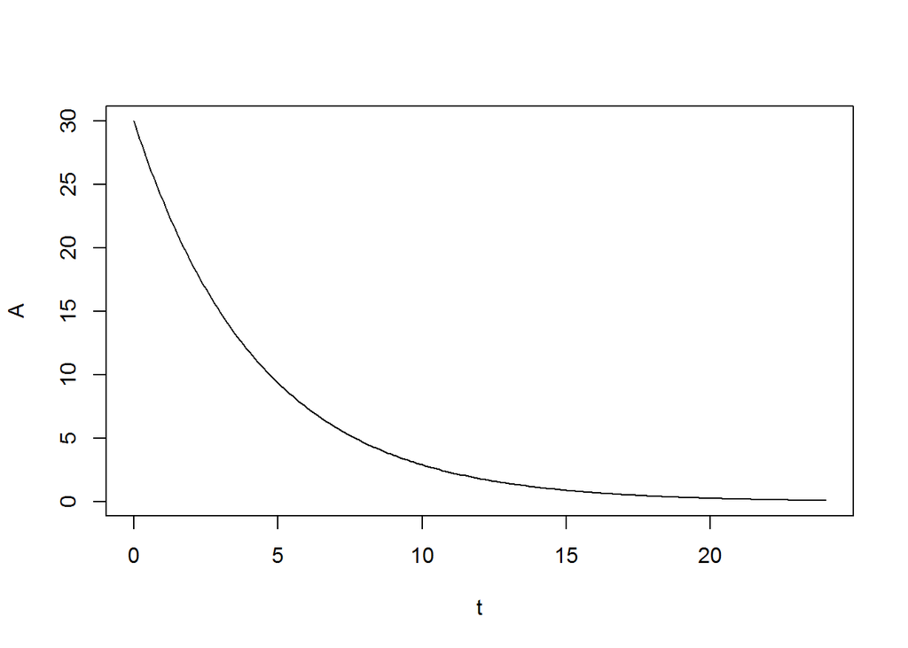

```r
A <- rep(0, Nstep+1)
A[1] <- 30
for (i in 1:Nstep){
  A[i+1] <- A[i] + dt*acetamin.model(k,A[i],s)
}
plot(t,A, type="l")
```

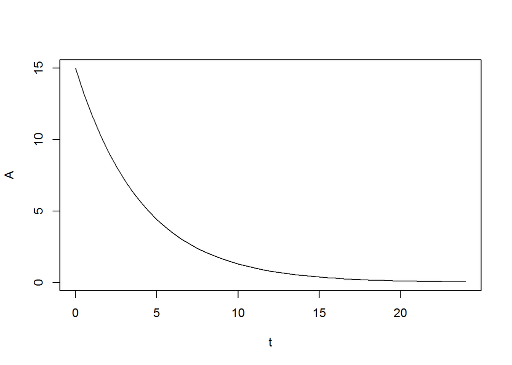

```r
dt <- 0.5
Tmax <- 24
Nstep <- Tmax/dt
t <- dt*(0:Nstep)
A <- rep(0, Nstep+1)
A[1] <- 15
for (i in 1:Nstep){
  A[i+1] <- A[i] + dt*acetamin.model(k,A[i],s)
}
plot(t,A, type="l")
```

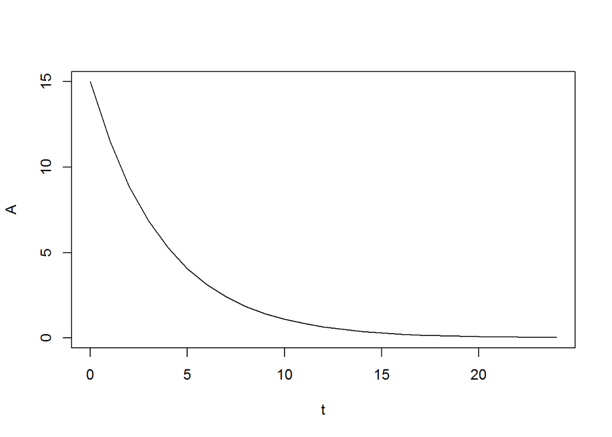

```r
dt <- 1
Tmax <- 24
Nstep <- Tmax/dt
t <- dt*(0:Nstep)
A <- rep(0, Nstep+1)
A[1] <- 15
for (i in 1:Nstep){
  A[i+1] <- A[i] + dt*acetamin.model(k,A[i],s)
}
plot(t,A, type="l")
```